# Risk Factor Analysis

## Outcome Variable

**Outcome Variable:** ever_swasted

## Predictor Variables

**Intervention Variable:** fage

**Adjustment Set:**

- arm
- W_mage
- meducyrs
- feducyrs
- W_mhtcm
- W_mwtkg
- W_mbmi
- W_fhtcm
- single
- brthmon
- delta_W_mage
- delta_meducyrs
- delta_feducyrs
- delta_W_mhtcm
- delta_W_mwtkg
- delta_W_mbmi
- delta_W_fhtcm
- delta_single
- delta_brthmon

## Stratifying Variables

The analysis was stratified on these variable(s):

- agecat
- studyid
- country

## Data Summary

| agecat | studyid | country | fage | ever_swasted | n_cell | n |
| --- | --- | --- | --- | --- | --- | --- |
| 0-24 months | ki0047075b-MAL-ED | BANGLADESH | >=38 | 0 | 63 | 151 |
| 0-24 months | ki0047075b-MAL-ED | BANGLADESH | >=38 | 1 | 6 | 151 |
| 0-24 months | ki0047075b-MAL-ED | BANGLADESH | <32 | 0 | 28 | 151 |
| 0-24 months | ki0047075b-MAL-ED | BANGLADESH | <32 | 1 | 2 | 151 |
| 0-24 months | ki0047075b-MAL-ED | BANGLADESH | [32-38) | 0 | 46 | 151 |
| 0-24 months | ki0047075b-MAL-ED | BANGLADESH | [32-38) | 1 | 6 | 151 |
| 0-24 months | ki0047075b-MAL-ED | BRAZIL | >=38 | 0 | 30 | 79 |
| 0-24 months | ki0047075b-MAL-ED | BRAZIL | >=38 | 1 | 0 | 79 |
| 0-24 months | ki0047075b-MAL-ED | BRAZIL | <32 | 0 | 18 | 79 |
| 0-24 months | ki0047075b-MAL-ED | BRAZIL | <32 | 1 | 0 | 79 |
| 0-24 months | ki0047075b-MAL-ED | BRAZIL | [32-38) | 0 | 31 | 79 |
| 0-24 months | ki0047075b-MAL-ED | BRAZIL | [32-38) | 1 | 0 | 79 |
| 0-24 months | ki0047075b-MAL-ED | INDIA | >=38 | 0 | 33 | 161 |
| 0-24 months | ki0047075b-MAL-ED | INDIA | >=38 | 1 | 3 | 161 |
| 0-24 months | ki0047075b-MAL-ED | INDIA | <32 | 0 | 45 | 161 |
| 0-24 months | ki0047075b-MAL-ED | INDIA | <32 | 1 | 8 | 161 |
| 0-24 months | ki0047075b-MAL-ED | INDIA | [32-38) | 0 | 65 | 161 |
| 0-24 months | ki0047075b-MAL-ED | INDIA | [32-38) | 1 | 7 | 161 |
| 0-24 months | ki0047075b-MAL-ED | NEPAL | >=38 | 0 | 17 | 79 |
| 0-24 months | ki0047075b-MAL-ED | NEPAL | >=38 | 1 | 0 | 79 |
| 0-24 months | ki0047075b-MAL-ED | NEPAL | <32 | 0 | 13 | 79 |
| 0-24 months | ki0047075b-MAL-ED | NEPAL | <32 | 1 | 2 | 79 |
| 0-24 months | ki0047075b-MAL-ED | NEPAL | [32-38) | 0 | 46 | 79 |
| 0-24 months | ki0047075b-MAL-ED | NEPAL | [32-38) | 1 | 1 | 79 |
| 0-24 months | ki0047075b-MAL-ED | PERU | >=38 | 0 | 26 | 85 |
| 0-24 months | ki0047075b-MAL-ED | PERU | >=38 | 1 | 1 | 85 |
| 0-24 months | ki0047075b-MAL-ED | PERU | <32 | 0 | 28 | 85 |
| 0-24 months | ki0047075b-MAL-ED | PERU | <32 | 1 | 1 | 85 |
| 0-24 months | ki0047075b-MAL-ED | PERU | [32-38) | 0 | 29 | 85 |
| 0-24 months | ki0047075b-MAL-ED | PERU | [32-38) | 1 | 0 | 85 |

[output cut: 204 more lines]

The following strata were considered:

- agecat: 0-24 months, studyid: ki0047075b-MAL-ED, country: BANGLADESH
- agecat: 0-24 months, studyid: ki0047075b-MAL-ED, country: BRAZIL
- agecat: 0-24 months, studyid: ki0047075b-MAL-ED, country: INDIA
- agecat: 0-24 months, studyid: ki0047075b-MAL-ED, country: NEPAL
- agecat: 0-24 months, studyid: ki0047075b-MAL-ED, country: PERU
- agecat: 0-24 months, studyid: ki0047075b-MAL-ED, country: SOUTH AFRICA
- agecat: 0-24 months, studyid: ki0047075b-MAL-ED, country: TANZANIA, UNITED REPUBLIC OF
- agecat: 0-24 months, studyid: ki1000304b-SAS-CompFeed, country: INDIA
- agecat: 0-24 months, studyid: ki1000304b-SAS-FoodSuppl, country: INDIA
- agecat: 0-24 months, studyid: ki1119695-PROBIT, country: BELARUS
- agecat: 0-24 months, studyid: ki1135781-COHORTS, country: GUATEMALA
- agecat: 0-24 months, studyid: ki1135781-COHORTS, country: PHILIPPINES
- agecat: 0-24 months, studyid: ki1148112-LCNI-5, country: MALAWI
- agecat: 0-6 months, studyid: ki0047075b-MAL-ED, country: BANGLADESH
- agecat: 0-6 months, studyid: ki0047075b-MAL-ED, country: BRAZIL
- agecat: 0-6 months, studyid: ki0047075b-MAL-ED, country: INDIA
- agecat: 0-6 months, studyid: ki0047075b-MAL-ED, country: NEPAL
- agecat: 0-6 months, studyid: ki0047075b-MAL-ED, country: PERU
- agecat: 0-6 months, studyid: ki0047075b-MAL-ED, country: SOUTH AFRICA
- agecat: 0-6 months, studyid: ki0047075b-MAL-ED, country: TANZANIA, UNITED REPUBLIC OF
- agecat: 0-6 months, studyid: ki1000304b-SAS-CompFeed, country: INDIA
- agecat: 0-6 months, studyid: ki1000304b-SAS-FoodSuppl, country: INDIA
- agecat: 0-6 months, studyid: ki1119695-PROBIT, country: BELARUS
- agecat: 0-6 months, studyid: ki1135781-COHORTS, country: GUATEMALA
- agecat: 0-6 months, studyid: ki1135781-COHORTS, country: PHILIPPINES
- agecat: 0-6 months, studyid: ki1148112-LCNI-5, country: MALAWI
- agecat: 6-24 months, studyid: ki0047075b-MAL-ED, country: BANGLADESH
- agecat: 6-24 months, studyid: ki0047075b-MAL-ED, country: BRAZIL
- agecat: 6-24 months, studyid: ki0047075b-MAL-ED, country: INDIA
- agecat: 6-24 months, studyid: ki0047075b-MAL-ED, country: NEPAL
- agecat: 6-24 months, studyid: ki0047075b-MAL-ED, country: PERU
- agecat: 6-24 months, studyid: ki0047075b-MAL-ED, country: SOUTH AFRICA
- agecat: 6-24 months, studyid: ki0047075b-MAL-ED, country: TANZANIA, UNITED REPUBLIC OF
- agecat: 6-24 months, studyid: ki1000304b-SAS-CompFeed, country: INDIA
- agecat: 6-24 months, studyid: ki1000304b-SAS-FoodSuppl, country: INDIA
- agecat: 6-24 months, studyid: ki1119695-PROBIT, country: BELARUS
- agecat: 6-24 months, studyid: ki1135781-COHORTS, country: GUATEMALA
- agecat: 6-24 months, studyid: ki1135781-COHORTS, country: PHILIPPINES
- agecat: 6-24 months, studyid: ki1148112-LCNI-5, country: MALAWI

### Dropped Strata

Some strata were dropped due to rare outcomes:

- agecat: 0-24 months, studyid: ki0047075b-MAL-ED, country: BANGLADESH
- agecat: 0-24 months, studyid: ki0047075b-MAL-ED, country: BRAZIL
- agecat: 0-24 months, studyid: ki0047075b-MAL-ED, country: INDIA
- agecat: 0-24 months, studyid: ki0047075b-MAL-ED, country: NEPAL
- agecat: 0-24 months, studyid: ki0047075b-MAL-ED, country: PERU
- agecat: 0-24 months, studyid: ki0047075b-MAL-ED, country: SOUTH AFRICA
- agecat: 0-24 months, studyid: ki0047075b-MAL-ED, country: TANZANIA, UNITED REPUBLIC OF
- agecat: 0-24 months, studyid: ki1148112-LCNI-5, country: MALAWI
- agecat: 0-6 months, studyid: ki0047075b-MAL-ED, country: BANGLADESH
- agecat: 0-6 months, studyid: ki0047075b-MAL-ED, country: BRAZIL
- agecat: 0-6 months, studyid: ki0047075b-MAL-ED, country: INDIA
- agecat: 0-6 months, studyid: ki0047075b-MAL-ED, country: NEPAL
- agecat: 0-6 months, studyid: ki0047075b-MAL-ED, country: PERU
- agecat: 0-6 months, studyid: ki0047075b-MAL-ED, country: SOUTH AFRICA
- agecat: 0-6 months, studyid: ki0047075b-MAL-ED, country: TANZANIA, UNITED REPUBLIC OF
- agecat: 0-6 months, studyid: ki1148112-LCNI-5, country: MALAWI
- agecat: 6-24 months, studyid: ki0047075b-MAL-ED, country: BANGLADESH
- agecat: 6-24 months, studyid: ki0047075b-MAL-ED, country: BRAZIL
- agecat: 6-24 months, studyid: ki0047075b-MAL-ED, country: INDIA
- agecat: 6-24 months, studyid: ki0047075b-MAL-ED, country: NEPAL
- agecat: 6-24 months, studyid: ki0047075b-MAL-ED, country: PERU
- agecat: 6-24 months, studyid: ki0047075b-MAL-ED, country: SOUTH AFRICA
- agecat: 6-24 months, studyid: ki0047075b-MAL-ED, country: TANZANIA, UNITED REPUBLIC OF
- agecat: 6-24 months, studyid: ki1119695-PROBIT, country: BELARUS
- agecat: 6-24 months, studyid: ki1148112-LCNI-5, country: MALAWI

## Methods Detail

We’re interested in the causal parameters $E[Y_a]$ for all values of $a \in \mathcal{A}$. These parameters represent the mean outcome if, possibly contrary to fact, we intervened to set all units to have $A=a$. Under the randomization and positivity assumptions, these are identified by the statistical parameters $\psi_a=E_W[E_{Y|A,W}(Y|A=a,W)]$. In addition, we’re interested in the mean of $Y$, $E[Y]$ under no intervention (the observed mean). We will estimate these parameters by using SuperLearner to fit the relevant likelihood factors – $E_{Y|A,W}(Y|A=a,W)$ and $p(A=a|W)$, and then updating our likelihood fit using a joint TMLE.

For unadjusted analyses ($W=\{\}$), initial likelihoods were estimated using Lrnr_glm to estimate the simple $E(Y|A)$ and Lrnr_mean to estimate $p(A)$. For adjusted analyses, a small library containing Lrnr_glmnet, Lrnr_xgboost, and Lrnr_mean was used.

Having estimated these parameters, we will then use the delta method to estimate relative risks and attributable risks relative to a prespecified baseline level of $A$.

# Results Detail

## Results Plots

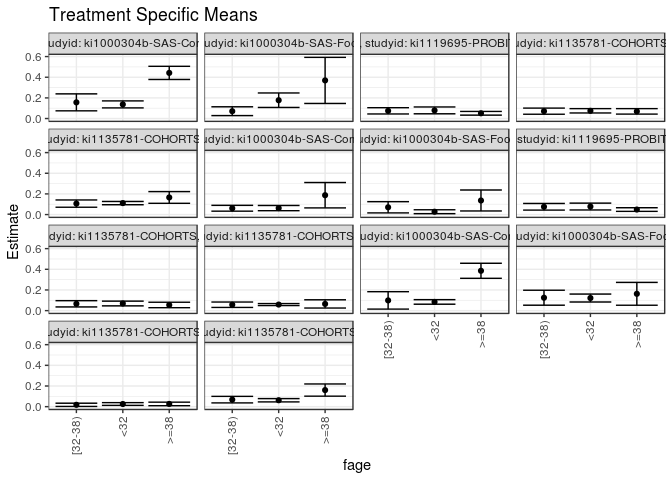

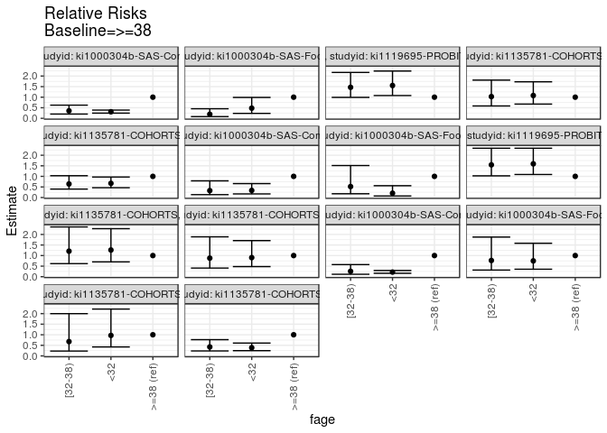

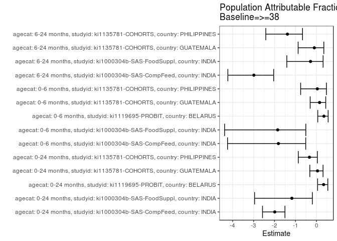

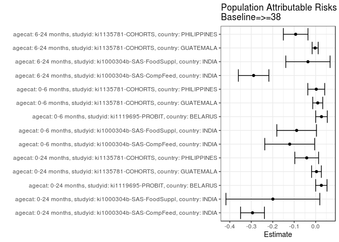

## Results Table

### Parameter: TSM

| agecat | studyid | country | intervention_level | baseline_level | estimate | ci_lower | ci_upper |
| --- | --- | --- | --- | --- | --- | --- | --- |
| 0-24 months | ki1000304b-SAS-CompFeed | INDIA | >=38 | NA | 0.4418587 | 0.3782229 | 0.5054946 |
| 0-24 months | ki1000304b-SAS-CompFeed | INDIA | <32 | NA | 0.1369603 | 0.1030612 | 0.1708594 |
| 0-24 months | ki1000304b-SAS-CompFeed | INDIA | [32-38) | NA | 0.1566745 | 0.0745043 | 0.2388447 |
| 0-24 months | ki1000304b-SAS-FoodSuppl | INDIA | >=38 | NA | 0.3691788 | 0.1460203 | 0.5923373 |
| 0-24 months | ki1000304b-SAS-FoodSuppl | INDIA | <32 | NA | 0.1772380 | 0.1071432 | 0.2473328 |
| 0-24 months | ki1000304b-SAS-FoodSuppl | INDIA | [32-38) | NA | 0.0710127 | 0.0284621 | 0.1135633 |
| 0-24 months | ki1119695-PROBIT | BELARUS | >=38 | NA | 0.0508471 | 0.0329597 | 0.0687346 |
| 0-24 months | ki1119695-PROBIT | BELARUS | <32 | NA | 0.0789478 | 0.0460142 | 0.1118814 |
| 0-24 months | ki1119695-PROBIT | BELARUS | [32-38) | NA | 0.0746080 | 0.0440750 | 0.1051411 |
| 0-24 months | ki1135781-COHORTS | GUATEMALA | >=38 | NA | 0.0694436 | 0.0430937 | 0.0957935 |
| 0-24 months | ki1135781-COHORTS | GUATEMALA | <32 | NA | 0.0749312 | 0.0540311 | 0.0958314 |
| 0-24 months | ki1135781-COHORTS | GUATEMALA | [32-38) | NA | 0.0713814 | 0.0415374 | 0.1012253 |
| 0-24 months | ki1135781-COHORTS | PHILIPPINES | >=38 | NA | 0.1658647 | 0.1091858 | 0.2225435 |
| 0-24 months | ki1135781-COHORTS | PHILIPPINES | <32 | NA | 0.1111751 | 0.0953392 | 0.1270111 |
| 0-24 months | ki1135781-COHORTS | PHILIPPINES | [32-38) | NA | 0.1063530 | 0.0713108 | 0.1413952 |
| 0-6 months | ki1000304b-SAS-CompFeed | INDIA | >=38 | NA | 0.1875000 | 0.0647763 | 0.3102237 |
| 0-6 months | ki1000304b-SAS-CompFeed | INDIA | <32 | NA | 0.0627981 | 0.0374492 | 0.0881470 |
| 0-6 months | ki1000304b-SAS-CompFeed | INDIA | [32-38) | NA | 0.0612245 | 0.0329168 | 0.0895321 |
| 0-6 months | ki1000304b-SAS-FoodSuppl | INDIA | >=38 | NA | 0.1363636 | 0.0348425 | 0.2378848 |
| 0-6 months | ki1000304b-SAS-FoodSuppl | INDIA | <32 | NA | 0.0276817 | 0.0087443 | 0.0466190 |
| 0-6 months | ki1000304b-SAS-FoodSuppl | INDIA | [32-38) | NA | 0.0705882 | 0.0160716 | 0.1251049 |
| 0-6 months | ki1119695-PROBIT | BELARUS | >=38 | NA | 0.0487834 | 0.0312407 | 0.0663261 |
| 0-6 months | ki1119695-PROBIT | BELARUS | <32 | NA | 0.0777241 | 0.0445479 | 0.1109002 |
| 0-6 months | ki1119695-PROBIT | BELARUS | [32-38) | NA | 0.0754166 | 0.0432563 | 0.1075769 |
| 0-6 months | ki1135781-COHORTS | GUATEMALA | >=38 | NA | 0.0546320 | 0.0281408 | 0.0811233 |
| 0-6 months | ki1135781-COHORTS | GUATEMALA | <32 | NA | 0.0690068 | 0.0460935 | 0.0919200 |
| 0-6 months | ki1135781-COHORTS | GUATEMALA | [32-38) | NA | 0.0660045 | 0.0356840 | 0.0963250 |
| 0-6 months | ki1135781-COHORTS | PHILIPPINES | >=38 | NA | 0.0649013 | 0.0250589 | 0.1047437 |
| 0-6 months | ki1135781-COHORTS | PHILIPPINES | <32 | NA | 0.0586171 | 0.0487415 | 0.0684928 |
| 0-6 months | ki1135781-COHORTS | PHILIPPINES | [32-38) | NA | 0.0570073 | 0.0309910 | 0.0830235 |
| 6-24 months | ki1000304b-SAS-CompFeed | INDIA | >=38 | NA | 0.3856676 | 0.3128741 | 0.4584610 |
| 6-24 months | ki1000304b-SAS-CompFeed | INDIA | <32 | NA | 0.0841037 | 0.0621896 | 0.1060177 |
| 6-24 months | ki1000304b-SAS-CompFeed | INDIA | [32-38) | NA | 0.0988587 | 0.0146081 | 0.1831093 |
| 6-24 months | ki1000304b-SAS-FoodSuppl | INDIA | >=38 | NA | 0.1627907 | 0.0523100 | 0.2732714 |
| 6-24 months | ki1000304b-SAS-FoodSuppl | INDIA | <32 | NA | 0.1218638 | 0.0834307 | 0.1602969 |
| 6-24 months | ki1000304b-SAS-FoodSuppl | INDIA | [32-38) | NA | 0.1250000 | 0.0524390 | 0.1975610 |
| 6-24 months | ki1135781-COHORTS | GUATEMALA | >=38 | NA | 0.0264706 | 0.0093999 | 0.0435413 |
| 6-24 months | ki1135781-COHORTS | GUATEMALA | <32 | NA | 0.0256410 | 0.0123773 | 0.0389047 |
| 6-24 months | ki1135781-COHORTS | GUATEMALA | [32-38) | NA | 0.0179211 | 0.0023476 | 0.0334947 |
| 6-24 months | ki1135781-COHORTS | PHILIPPINES | >=38 | NA | 0.1605047 | 0.1015201 | 0.2194893 |
| 6-24 months | ki1135781-COHORTS | PHILIPPINES | <32 | NA | 0.0621665 | 0.0462042 | 0.0781287 |
| 6-24 months | ki1135781-COHORTS | PHILIPPINES | [32-38) | NA | 0.0680901 | 0.0363746 | 0.0998056 |

### Parameter: E(Y)

| agecat | studyid | country | intervention_level | baseline_level | estimate | ci_lower | ci_upper |
| --- | --- | --- | --- | --- | --- | --- | --- |
| 0-24 months | ki1000304b-SAS-CompFeed | INDIA | NA | NA | 0.1476821 | 0.1188009 | 0.1765633 |
| 0-24 months | ki1000304b-SAS-FoodSuppl | INDIA | NA | NA | 0.1698565 | 0.1338154 | 0.2058975 |
| 0-24 months | ki1119695-PROBIT | BELARUS | NA | NA | 0.0773437 | 0.0450708 | 0.1096165 |
| 0-24 months | ki1135781-COHORTS | GUATEMALA | NA | NA | 0.0731518 | 0.0589094 | 0.0873941 |
| 0-24 months | ki1135781-COHORTS | PHILIPPINES | NA | NA | 0.1241919 | 0.1122665 | 0.1361173 |
| 0-6 months | ki1000304b-SAS-CompFeed | INDIA | NA | NA | 0.0665779 | 0.0427569 | 0.0903989 |
| 0-6 months | ki1000304b-SAS-FoodSuppl | INDIA | NA | NA | 0.0478469 | 0.0273607 | 0.0683330 |
| 0-6 months | ki1119695-PROBIT | BELARUS | NA | NA | 0.0758833 | 0.0434683 | 0.1082982 |
| 0-6 months | ki1135781-COHORTS | GUATEMALA | NA | NA | 0.0642648 | 0.0492598 | 0.0792699 |
| 0-6 months | ki1135781-COHORTS | PHILIPPINES | NA | NA | 0.0677332 | 0.0586452 | 0.0768211 |
| 6-24 months | ki1000304b-SAS-CompFeed | INDIA | NA | NA | 0.0966811 | 0.0731505 | 0.1202117 |
| 6-24 months | ki1000304b-SAS-FoodSuppl | INDIA | NA | NA | 0.1268657 | 0.0942904 | 0.1594410 |
| 6-24 months | ki1135781-COHORTS | GUATEMALA | NA | NA | 0.0240343 | 0.0152359 | 0.0328328 |
| 6-24 months | ki1135781-COHORTS | PHILIPPINES | NA | NA | 0.0672794 | 0.0578635 | 0.0766953 |

### Parameter: RR

| agecat | studyid | country | intervention_level | baseline_level | estimate | ci_lower | ci_upper |
| --- | --- | --- | --- | --- | --- | --- | --- |
| 0-24 months | ki1000304b-SAS-CompFeed | INDIA | >=38 | >=38 | 1.0000000 | 1.0000000 | 1.0000000 |
| 0-24 months | ki1000304b-SAS-CompFeed | INDIA | <32 | >=38 | 0.3099639 | 0.2460236 | 0.3905221 |
| 0-24 months | ki1000304b-SAS-CompFeed | INDIA | [32-38) | >=38 | 0.3545805 | 0.2019109 | 0.6226869 |
| 0-24 months | ki1000304b-SAS-FoodSuppl | INDIA | >=38 | >=38 | 1.0000000 | 1.0000000 | 1.0000000 |
| 0-24 months | ki1000304b-SAS-FoodSuppl | INDIA | <32 | >=38 | 0.4800872 | 0.2331652 | 0.9884998 |
| 0-24 months | ki1000304b-SAS-FoodSuppl | INDIA | [32-38) | >=38 | 0.1923531 | 0.0819871 | 0.4512874 |
| 0-24 months | ki1119695-PROBIT | BELARUS | >=38 | >=38 | 1.0000000 | 1.0000000 | 1.0000000 |
| 0-24 months | ki1119695-PROBIT | BELARUS | <32 | >=38 | 1.5526496 | 1.0774009 | 2.2375337 |
| 0-24 months | ki1119695-PROBIT | BELARUS | [32-38) | >=38 | 1.4673000 | 0.9913595 | 2.1717342 |
| 0-24 months | ki1135781-COHORTS | GUATEMALA | >=38 | >=38 | 1.0000000 | 1.0000000 | 1.0000000 |
| 0-24 months | ki1135781-COHORTS | GUATEMALA | <32 | >=38 | 1.0790221 | 0.6736680 | 1.7282826 |
| 0-24 months | ki1135781-COHORTS | GUATEMALA | [32-38) | >=38 | 1.0279039 | 0.5844362 | 1.8078730 |
| 0-24 months | ki1135781-COHORTS | PHILIPPINES | >=38 | >=38 | 1.0000000 | 1.0000000 | 1.0000000 |
| 0-24 months | ki1135781-COHORTS | PHILIPPINES | <32 | >=38 | 0.6702762 | 0.4629283 | 0.9704963 |
| 0-24 months | ki1135781-COHORTS | PHILIPPINES | [32-38) | >=38 | 0.6412034 | 0.3988161 | 1.0309059 |
| 0-6 months | ki1000304b-SAS-CompFeed | INDIA | >=38 | >=38 | 1.0000000 | 1.0000000 | 1.0000000 |
| 0-6 months | ki1000304b-SAS-CompFeed | INDIA | <32 | >=38 | 0.3349232 | 0.1704948 | 0.6579294 |
| 0-6 months | ki1000304b-SAS-CompFeed | INDIA | [32-38) | >=38 | 0.3265306 | 0.1350830 | 0.7893089 |
| 0-6 months | ki1000304b-SAS-FoodSuppl | INDIA | >=38 | >=38 | 1.0000000 | 1.0000000 | 1.0000000 |
| 0-6 months | ki1000304b-SAS-FoodSuppl | INDIA | <32 | >=38 | 0.2029988 | 0.0738566 | 0.5579534 |
| 0-6 months | ki1000304b-SAS-FoodSuppl | INDIA | [32-38) | >=38 | 0.5176471 | 0.1770741 | 1.5132562 |
| 0-6 months | ki1119695-PROBIT | BELARUS | >=38 | >=38 | 1.0000000 | 1.0000000 | 1.0000000 |
| 0-6 months | ki1119695-PROBIT | BELARUS | <32 | >=38 | 1.5932481 | 1.0884466 | 2.3321674 |
| 0-6 months | ki1119695-PROBIT | BELARUS | [32-38) | >=38 | 1.5459473 | 1.0248706 | 2.3319558 |
| 0-6 months | ki1135781-COHORTS | GUATEMALA | >=38 | >=38 | 1.0000000 | 1.0000000 | 1.0000000 |
| 0-6 months | ki1135781-COHORTS | GUATEMALA | <32 | >=38 | 1.2631193 | 0.7021494 | 2.2722660 |
| 0-6 months | ki1135781-COHORTS | GUATEMALA | [32-38) | >=38 | 1.2081653 | 0.6197191 | 2.3553630 |
| 0-6 months | ki1135781-COHORTS | PHILIPPINES | >=38 | >=38 | 1.0000000 | 1.0000000 | 1.0000000 |
| 0-6 months | ki1135781-COHORTS | PHILIPPINES | <32 | >=38 | 0.9031738 | 0.4778376 | 1.7071135 |
| 0-6 months | ki1135781-COHORTS | PHILIPPINES | [32-38) | >=38 | 0.8783691 | 0.4088578 | 1.8870430 |
| 6-24 months | ki1000304b-SAS-CompFeed | INDIA | >=38 | >=38 | 1.0000000 | 1.0000000 | 1.0000000 |
| 6-24 months | ki1000304b-SAS-CompFeed | INDIA | <32 | >=38 | 0.2180729 | 0.1620779 | 0.2934132 |
| 6-24 months | ki1000304b-SAS-CompFeed | INDIA | [32-38) | >=38 | 0.2563315 | 0.1145974 | 0.5733621 |
| 6-24 months | ki1000304b-SAS-FoodSuppl | INDIA | >=38 | >=38 | 1.0000000 | 1.0000000 | 1.0000000 |
| 6-24 months | ki1000304b-SAS-FoodSuppl | INDIA | <32 | >=38 | 0.7485919 | 0.3541879 | 1.5821822 |
| 6-24 months | ki1000304b-SAS-FoodSuppl | INDIA | [32-38) | >=38 | 0.7678571 | 0.3143617 | 1.8755611 |
| 6-24 months | ki1135781-COHORTS | GUATEMALA | >=38 | >=38 | 1.0000000 | 1.0000000 | 1.0000000 |
| 6-24 months | ki1135781-COHORTS | GUATEMALA | <32 | >=38 | 0.9686610 | 0.4237702 | 2.2141811 |
| 6-24 months | ki1135781-COHORTS | GUATEMALA | [32-38) | >=38 | 0.6770211 | 0.2294185 | 1.9979104 |
| 6-24 months | ki1135781-COHORTS | PHILIPPINES | >=38 | >=38 | 1.0000000 | 1.0000000 | 1.0000000 |
| 6-24 months | ki1135781-COHORTS | PHILIPPINES | <32 | >=38 | 0.3873186 | 0.2473689 | 0.6064454 |
| 6-24 months | ki1135781-COHORTS | PHILIPPINES | [32-38) | >=38 | 0.4242248 | 0.2343151 | 0.7680541 |

### Parameter: PAR

| agecat | studyid | country | intervention_level | baseline_level | estimate | ci_lower | ci_upper |
| --- | --- | --- | --- | --- | --- | --- | --- |
| 0-24 months | ki1000304b-SAS-CompFeed | INDIA | >=38 | NA | -0.2941766 | -0.3498808 | -0.2384724 |
| 0-24 months | ki1000304b-SAS-FoodSuppl | INDIA | >=38 | NA | -0.1993223 | -0.4179780 | 0.0193334 |
| 0-24 months | ki1119695-PROBIT | BELARUS | >=38 | NA | 0.0264965 | -0.0000666 | 0.0530596 |
| 0-24 months | ki1135781-COHORTS | GUATEMALA | >=38 | NA | 0.0037081 | -0.0190300 | 0.0264463 |
| 0-24 months | ki1135781-COHORTS | PHILIPPINES | >=38 | NA | -0.0416728 | -0.0970367 | 0.0136912 |
| 0-6 months | ki1000304b-SAS-CompFeed | INDIA | >=38 | NA | -0.1209221 | -0.2371560 | -0.0046882 |
| 0-6 months | ki1000304b-SAS-FoodSuppl | INDIA | >=38 | NA | -0.0885167 | -0.1810177 | 0.0039842 |
| 0-6 months | ki1119695-PROBIT | BELARUS | >=38 | NA | 0.0270998 | 0.0000444 | 0.0541553 |
| 0-6 months | ki1135781-COHORTS | GUATEMALA | >=38 | NA | 0.0096328 | -0.0136499 | 0.0329156 |
| 0-6 months | ki1135781-COHORTS | PHILIPPINES | >=38 | NA | 0.0028319 | -0.0364258 | 0.0420896 |
| 6-24 months | ki1000304b-SAS-CompFeed | INDIA | >=38 | NA | -0.2889865 | -0.3600491 | -0.2179238 |
| 6-24 months | ki1000304b-SAS-FoodSuppl | INDIA | >=38 | NA | -0.0359250 | -0.1391525 | 0.0673024 |
| 6-24 months | ki1135781-COHORTS | GUATEMALA | >=38 | NA | -0.0024363 | -0.0165334 | 0.0116609 |
| 6-24 months | ki1135781-COHORTS | PHILIPPINES | >=38 | NA | -0.0932253 | -0.1506348 | -0.0358158 |

### Parameter: PAF

| agecat | studyid | country | intervention_level | baseline_level | estimate | ci_lower | ci_upper |
| --- | --- | --- | --- | --- | --- | --- | --- |
| 0-24 months | ki1000304b-SAS-CompFeed | INDIA | >=38 | NA | -1.9919581 | -2.5750080 | -1.5039981 |
| 0-24 months | ki1000304b-SAS-FoodSuppl | INDIA | >=38 | NA | -1.1734750 | -2.9536279 | -0.1948503 |
| 0-24 months | ki1119695-PROBIT | BELARUS | >=38 | NA | 0.3425816 | 0.0557623 | 0.5422774 |
| 0-24 months | ki1135781-COHORTS | GUATEMALA | >=38 | NA | 0.0506908 | -0.3167513 | 0.3155974 |
| 0-24 months | ki1135781-COHORTS | PHILIPPINES | >=38 | NA | -0.3355515 | -0.8662141 | 0.0442159 |
| 0-6 months | ki1000304b-SAS-CompFeed | INDIA | >=38 | NA | -1.8162500 | -4.2450610 | -0.5121395 |
| 0-6 months | ki1000304b-SAS-FoodSuppl | INDIA | >=38 | NA | -1.8500000 | -4.3856396 | -0.5081774 |
| 0-6 months | ki1119695-PROBIT | BELARUS | >=38 | NA | 0.3571255 | 0.0622213 | 0.5592909 |
| 0-6 months | ki1135781-COHORTS | GUATEMALA | >=38 | NA | 0.1498925 | -0.2994089 | 0.4438373 |
| 0-6 months | ki1135781-COHORTS | PHILIPPINES | >=38 | NA | 0.0418093 | -0.7540108 | 0.4765543 |
| 6-24 months | ki1000304b-SAS-CompFeed | INDIA | >=38 | NA | -2.9890690 | -4.2297318 | -2.0427319 |
| 6-24 months | ki1000304b-SAS-FoodSuppl | INDIA | >=38 | NA | -0.2831737 | -1.4153842 | 0.3183135 |
| 6-24 months | ki1135781-COHORTS | GUATEMALA | >=38 | NA | -0.1013655 | -0.8740452 | 0.3527338 |
| 6-24 months | ki1135781-COHORTS | PHILIPPINES | >=38 | NA | -1.3856438 | -2.4187049 | -0.6647522 |